# Assignments Topic 2

```python
import numpy as np
import matplotlib.pyplot as plt
import random
```

Stochastic simulations of the PQC and protein aggregation .

1. Modify your Gillespie code to include PQC (Agg PQC--|Aggs: negative feedback). Find parameter regime where the unfolded proteins are at low ss. levels
2. Add the effect of aggregates on PQC (Agg --|PQC--|Aggs: positive feedback). Can you

reproduce observations by Krohn et al, JCI (delayed spike, see ppt)?

```python
def Mt(f):
    " Calculate the total mass of polymers"
    return np.sum(np.arange(len(f))*f)


def calc_assoc_rates(ka,mt,f):
    '''For every size j, calculat the rate at which new polymers of length
    are created because of association of a polymer of length j-1.

    Returns an array with the association rates for each j.'''

    assoc_rates = np.zeros(len(f))
    for j in range(1,len(f)):
        assoc_rates[j] = ka*mt*f[j-1]

    return(assoc_rates)

def calc_dissoc_rates(kd,f):
    '''For every size j, calculat the rate at which new polymers of length
    are created because of association of a polymer of length j-1.

    Returns an array with the association rates for each j.'''

    dissoc_rates = np.zeros(len(f))
    for j in range(0,len(f)-1):
        dissoc_rates[j] = 2*kd*f[j+1]

    return(dissoc_rates)


def run_gillespie(m0=100,  kn=1e-5,ka=1e-3,kd=2e-1,nc=3,tmax=200,jmax=10,
                 p=0.1,ct=0.1,K=50,h=2):
    t=0

    f = np.zeros(jmax)
    ft = [np.copy(f)]
    tt = [t]
    Mtt = [Mt(f)]
    mtt = [m0-Mt(f)]

    total_rate = 1
    while t <= tmax and total_rate > 0:
        #1. update rates
        mt = (m0 - Mt(f)) # Free monomers
        nucl_rate = kn*mt**nc

        assoc_rates = calc_assoc_rates(ka, mt, f)
        dissoc_rates = calc_dissoc_rates(kd,f)

        creation_rate = p  #Constant creation rate of new free monomers
        transport_rate = ct/(1+(Mt(f)/K)**h)*mt
                    #rate of transport, which decreases if we increase the mass of fibrils.




        total_rate = nucl_rate + np.sum(assoc_rates) + np.sum(dissoc_rates)+creation_rate+transport_rate
#         print(total_rate)
#         print(t)
        if total_rate <= 0:
            print("total_rate = ", total_rate)
            break

        #2. time to next reaction.
        rn1 = random.random()
        tau = -1/total_rate*np.log(rn1)

        #3. find which reaction to do.
        rn2 = random.random()

        done = False

        if(rn2 < nucl_rate/total_rate):
            f[nc] = f[nc] + 1 # creation reaction
            done = True

        else:
            current_rate = nucl_rate
            for jj in range(nc+1,jmax):
                current_rate = current_rate + assoc_rates[jj]
                if (not done) and (rn2 < current_rate / total_rate):
                    f[jj] = f[jj]+1
                    f[jj-1] = f[jj-1]-1
                    done = True
                    break

            for jj in range(nc,jmax-1):
                current_rate = current_rate + dissoc_rates[jj]
                if (not done) and (rn2 < current_rate / total_rate):
                    f[jj] = f[jj]+1
                    f[jj+1] = f[jj+1]-1
                    done = True
                    break

            current_rate = current_rate + creation_rate

            if not(done) and (rn2 < current_rate/total_rate):
                m0 = m0+1
                mt=mt+1
                done = True

            current_rate = current_rate + transport_rate
            if not(done) and (rn2 < current_rate /total_rate):
                m0=m0-1
                mt=mt-1
                done=True

        #4. advance time
        t = t+tau

        #5. save values
        ft.append(np.copy(f))
        Mtt.append(Mt(f))
        tt.append(t)
        mtt.append(mt)

    return(tt,np.array(ft),Mtt,mtt)
```

```python
def plot_Mtt(tt,Mtt):
    plt.plot(tt,Mtt)
    plt.xlabel("Time")
    plt.ylabel("M")
#     plt.ylim(0,100)
    plt.show()

def plot_mtt(tt,mtt):
    plt.plot(tt,mtt)
    plt.xlabel("Time")
    plt.ylabel("m")
#     plt.ylim(0,100)
    plt.show()

def plot_ft_history(tt,ft):
    t_idx = 1# index
    colors = plt.cm.Greens(np.linspace(0, 1, len(tt)))

    for t_idx in range(len(tt)):
        color = colors[t_idx]
        plt.plot(ft[t_idx,:],color = color,alpha=t_idx/len(tt))

    plt.xlabel('j, polymer length')
    plt.ylabel('f(j), number of polymers of lenght j')

def plot_ft(ft):
    plt.plot(ft[-1])
    plt.xlabel('j, polymer length')
    plt.ylabel('f(j), number of polymers of lenght j')
```

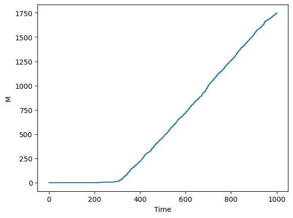

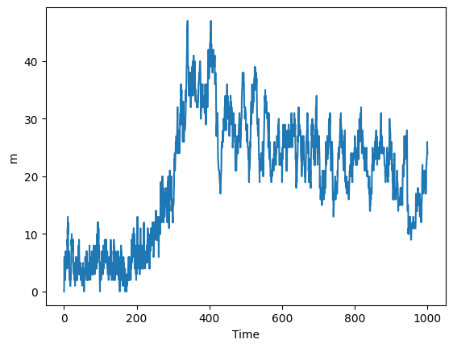

```
1747.0
```

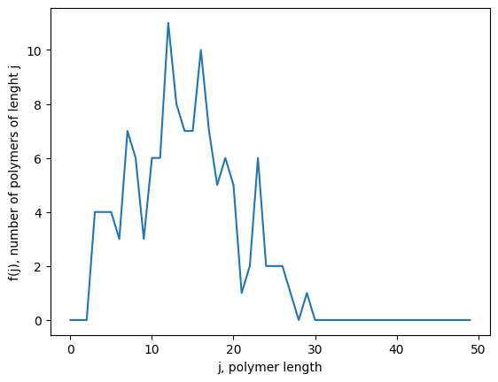

```python
random.seed(144)

tt,ft,Mtt,mtt = run_gillespie(m0=0,
                          kn=1e-5,
                          ka=0.001,
                          kd=0, #No dissociation
                          nc=3,
                          tmax=1000,
                          jmax=50,
                          p=2.5,
                          ct=0.5,
                          K=5,
                          h=2


                         )
plot_Mtt(tt,Mtt)
plot_mtt(tt,mtt)
print(Mtt[-1])
plt.show()
plot_ft(ft)
```

The PQC transport of monomers explains the time delay. Making $c_t$ bigger increases the delay

1. Implement model for α-synuclein aggregation by Sneppen et al. presented in the lecture.

   a. Start with the model with 7 parameters and through parameter rescaling arrive to 4-parameter model

   b. In the presented version, protease production was assumed constant. How do the results change if you include the fact that protease is induced by

   ```
    i. Proto-fibrils (s)

    ii. Oligomers (ααα)

    iii. Fibrils, (F)
   ```

   c. Which of i-iii have a maximal impact on model outcome?

   d. How would you modify the model to include the effect of autophagy? How does this change the results?

```python
from scipy.integrate import solve_ivp
import numpy as np
import matplotlib.pyplot as plt
#parameters
gamma = 1 # Rate of loss of protase due to Fibrils
m = 25  #Rate of increase of fibrils (multiplied by 1/P)
sigma = 1  #Protofibril creation rate
nu = 1  #Protofibril creation from complex

#initial conditions
ic = [0,0,0]
t0 = 0

tmax = 200

def derivs(t,var):
    dvar = np.zeros(3)
    F,C,P = var
    dvar[0] = m/(1+P) - gamma * F*P
    dvar[1] = gamma*F*P - nu*C
    dvar[2] = sigma - P - gamma*F*P + nu*C
    return dvar



sol = solve_ivp(derivs,[t0, tmax], ic)
```

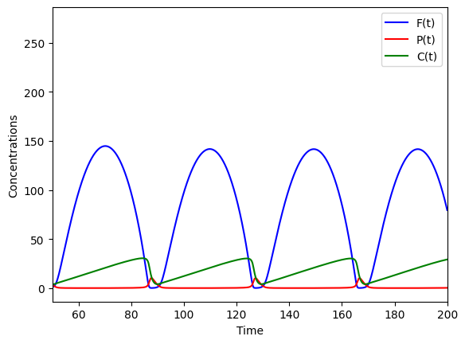

```python
plt.plot(sol.t, sol.y[0,:],label="F(t)",color="blue")
plt.plot(sol.t,sol.y[2,:],label="P(t)",color="red")
plt.plot(sol.t,sol.y[1,:],label="C(t)",color="green")
plt.xlim([50,200])
plt.legend()
plt.xlabel("Time")
plt.ylabel("Concentrations")
plt.show()
```

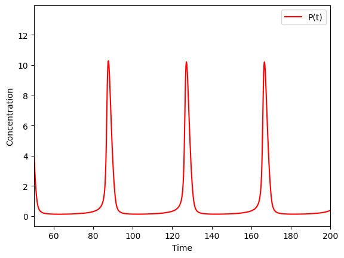

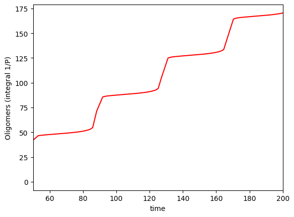

```python
plt.plot(sol.t,sol.y[2,:],color="red",label="P(t)")
plt.xlim([50,200])
plt.legend()
plt.xlabel("Time")
plt.ylabel("Concentration")
plt.show()

t_ind = np.linspace(2,len(sol.t),500).astype(int)
integrals=[]
tss=[]
for t_i in t_ind:
    ts = sol.t[1:t_i]
    vals = 1/sol.y[2,:][1:t_i]

    integral = np.trapz(1/vals,ts)
    integrals.append(integral)
    tss.append(ts[-1])

plt.plot(tss,  integrals,color="red")
plt.xlim([50,200])
plt.xlabel("time")
plt.ylabel("Oligomers (integral 1/P)")
```

### b) i. Protase production is induced by proto fibrils $s$

```python
from scipy.integrate import solve_ivp
import numpy as np
import matplotlib.pyplot as plt
#parameters
gamma = 1 # Rate of loss of protase due to Fibrils
m = 25  #Rate of increase of fibrils (multiplied by 1/P)
sigma = 1  #Protofibril creation rate
nu = 1  #Protofibril creation from complex
eta = 0.09

#initial conditions
ic = [0,0,0]
t0 = 0

#time to terminate simulation
tmax = 200

def derivs(t,var): # here we define the right-hand side of the equations
    ''' Input:
                            - t, a dummy parameter, requitred by solve_ivp
                            - var - an array witrh the values of variables X, Y at a givent time t
        Output:
                            -dvar derivatives defined by our diff. equations, i.e. the RHS expressions in the ODEs
    '''
    dvar = np.zeros(3)
    F,C,P = var
    dvar[0] = m/(1+P) - gamma * F*P
    dvar[1] = gamma*F*P - nu*C
    dvar[2] = sigma - P - gamma*F*P + nu*C + eta* (m/(1+P))
    return dvar


# Here we use SciPy's function sove_ivp , the solution (we called it sol below sol) is an object.
# The time is stored in sol.t, and variables in sol.y

sol = solve_ivp(derivs,[t0, tmax], ic)
```

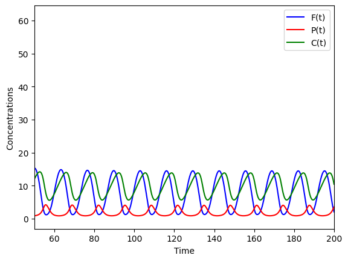

```python
plt.plot(sol.t, sol.y[0,:],label="F(t)",color="blue")
plt.plot(sol.t,sol.y[2,:],label="P(t)",color="red")
plt.plot(sol.t,sol.y[1,:],label="C(t)",color="green")
plt.xlim([50,200])
plt.legend()
plt.xlabel("Time")
plt.ylabel("Concentrations")
plt.show()
```

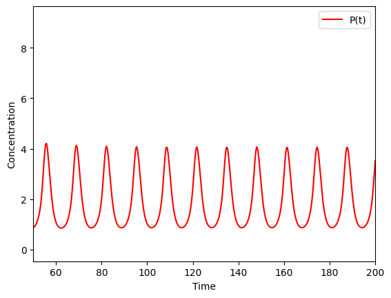

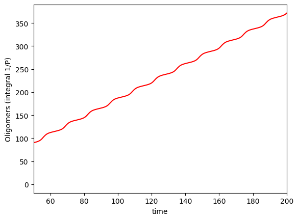

```python
plt.plot(sol.t,sol.y[2,:],color="red",label="P(t)")
plt.xlim([50,200])
plt.legend()
plt.xlabel("Time")
plt.ylabel("Concentration")
plt.show()

t_ind = np.linspace(2,len(sol.t),500).astype(int)
integrals=[]
tss=[]
for t_i in t_ind:
    ts = sol.t[1:t_i]
    vals = 1/sol.y[2,:][1:t_i]

    integral = np.trapz(1/vals,ts)
    integrals.append(integral)
    tss.append(ts[-1])

plt.plot(tss,  integrals,color="red")
plt.xlim([50,200])
plt.xlabel("time")
plt.ylabel("Oligomers (integral 1/P)")
```

The higher the eta, the smaller the height of the curves and the higher the frequency.

### b) iii. Protase production isinduced by fibrils

```python
from scipy.integrate import solve_ivp
import numpy as np
import matplotlib.pyplot as plt
#parameters
gamma = 1 # Rate of loss of protase due to Fibrils
m = 25  #Rate of increase of fibrils (multiplied by 1/P)
sigma = 1  #Protofibril creation rate
nu = 1  #Protofibril creation from complex
eta = 0.15

#initial conditions
ic = [0,0,0]
t0 = 0

#time to terminate simulation
tmax = 200

def derivs(t,var): # here we define the right-hand side of the equations
    ''' Input:
                            - t, a dummy parameter, requitred by solve_ivp
                            - var - an array witrh the values of variables X, Y at a givent time t
        Output:
                            -dvar derivatives defined by our diff. equations, i.e. the RHS expressions in the ODEs
    '''
    dvar = np.zeros(3)
    F,C,P = var
    dvar[0] = m/(1+P) - gamma * F*P
    dvar[1] = gamma*F*P - nu*C
    dvar[2] = sigma - P - gamma*F*P + nu*C + eta* F
    return dvar


# Here we use SciPy's function sove_ivp , the solution (we called it sol below sol) is an object.
# The time is stored in sol.t, and variables in sol.y

sol = solve_ivp(derivs,[t0, tmax], ic)
```

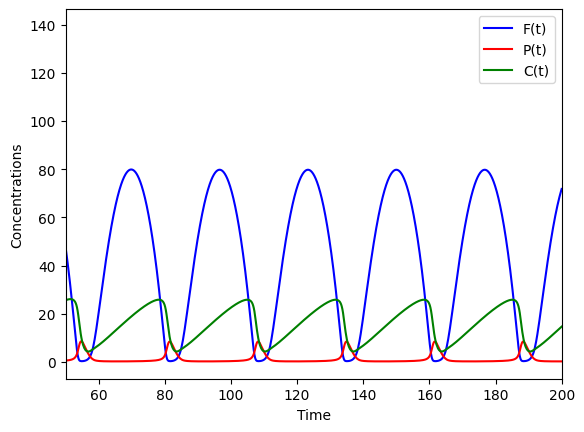

```python
plt.plot(sol.t, sol.y[0,:],label="F(t)",color="blue")
plt.plot(sol.t,sol.y[2,:],label="P(t)",color="red")
plt.plot(sol.t,sol.y[1,:],label="C(t)",color="green")
plt.xlim([50,200])
plt.legend()
plt.xlabel("Time")
plt.ylabel("Concentrations")
plt.show()
```

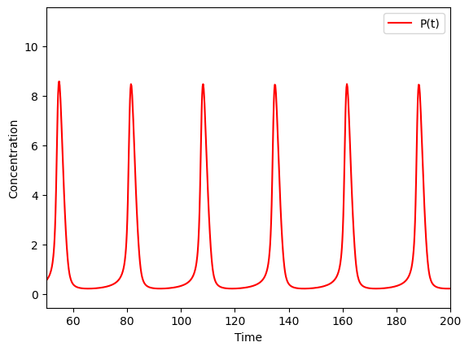

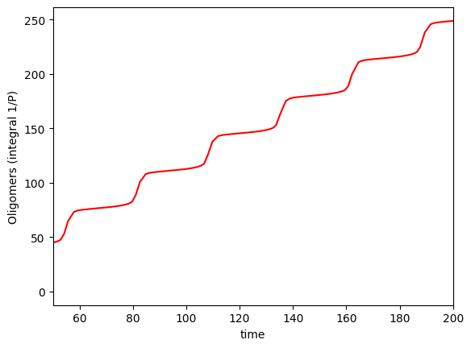

```python
plt.plot(sol.t,sol.y[2,:],color="red",label="P(t)")
plt.xlim([50,200])
plt.legend()
plt.xlabel("Time")
plt.ylabel("Concentration")
plt.show()

t_ind = np.linspace(2,len(sol.t),500).astype(int)
integrals=[]
tss=[]
for t_i in t_ind:
    ts = sol.t[1:t_i]
    vals = 1/sol.y[2,:][1:t_i]

    integral = np.trapz(1/vals,ts)
    integrals.append(integral)
    tss.append(ts[-1])

plt.plot(tss,  integrals,color="red")
plt.xlim([50,200])
plt.xlabel("time")
plt.ylabel("Oligomers (integral 1/P)")
```

```python
import numpy as np
import matplotlib.pyplot as plt
```